# Parasite Load

# 1 Translation of code from Stuart Baird

http://onlinelibrary.wiley.com/doi/10.1111/j.1558-5646.2012.01633.x/pdf WHERE ARE THE WORMY MICE? A REEXAMINATION OF HYBRID PARASITISM IN THE EUROPEAN HOUSE MOUSE HYBRID ZONE. Stuart J. E. Baird, Alexis Ribas, Milos Macholan, Tomas Albrecht, Jaroslav Pialek, Joelle Gouy de Bellocq

```r
rm(list=ls())
library(ggplot2)
library(reshape)
```

# 2 MeanLoad model: How does the mean load vary depending on the parameters?

We define a function where m1 is the load of Mmmusculus, Dm the additional load of Mmdomesticus alpha the hybridization effect (also called V in the article, We will investigate it later through MaxLikelihood) HI the hybrid index ( He = 2HI(1-HI) )

```r
MeanLoad <- function(m1,Dm,alpha,HI){
    (m1 + Dm*HI)*(1 - alpha*2*HI*(1 - HI))
}
```

First numerical example

```r
HI <- seq(from = 0, to = 1, by = 0.025)
ALPHA <- c(-0.4, -0.2, 0, 0.2, 0.4)
m <- as.data.frame(matrix(0, ncol = 5, nrow = 41))
i <- 1
for (alpha in c(-0.4, -0.2, 0, 0.2, 0.4)){
    m[i] <- MeanLoad(40,20,alpha,HI)
    i <- i+1
}

names(m) <- as.character(ALPHA)
m <- melt(m)
```

```
## Using  as id variables
```

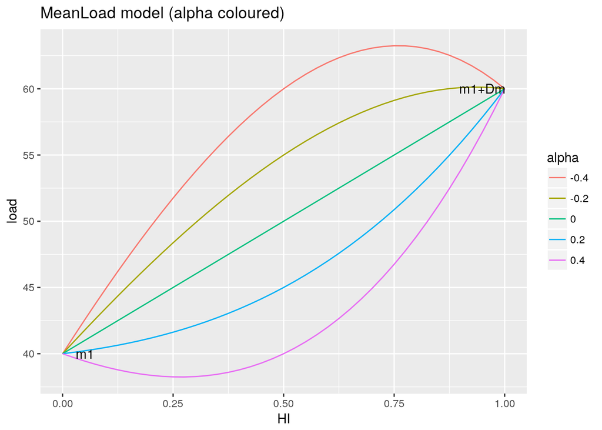

```r
names(m) <- c("alpha", "load")
m$HI <- rep(HI,5)

ggplot(m, aes(x=HI, y=load, group=alpha, color=alpha))+
    geom_line()+
    ggtitle("MeanLoad model (alpha coloured)")+
    annotate("text", x = 0.05, y = 40, label = "m1")+
    annotate("text", x = 0.95, y = 40+20, label = "m1+Dm")
```

# 3 NegativeBinomial parameterisation for MeanLoad

Probability of getting a mouse with a certain load, knowing: meanload : MeanLoad aggregation parameter : k We will investigate it later through MaxLik

For understanding: E(X)=k*(1-prob/prob) for negbino

E(X)=MeanLoad <=>k*(1-prob/prob)=MeanLoad <=>prob=k/(MeanLoad+k)

First, numerical application to check that the MeanLoad model has “the right” mean, being the input MeanLoad

```r
myvec <- vector()
for (k in 1:3){
    for (meanload in seq(from=20, to=40, by=10)){
        myvec <- c(myvec,(mean(rnbinom(10000, size=k, mu= meanload))))
        #(n=10000 number of observation)
    }
}
t(matrix(myvec,ncol=3))
```

```
##         [,1]    [,2]    [,3]
## [1,] 20.0673 29.9836 40.6826
## [2,] 19.8630 29.8631 39.8853
## [3,] 20.0484 29.8350 40.2208
```

Secondly, let’s have a look on the plot for different values: Notes : q is a quantile vector, meaning the values of probabilities for which we want to get an x. We set here 0 to 0.1 with a 0.001 step.

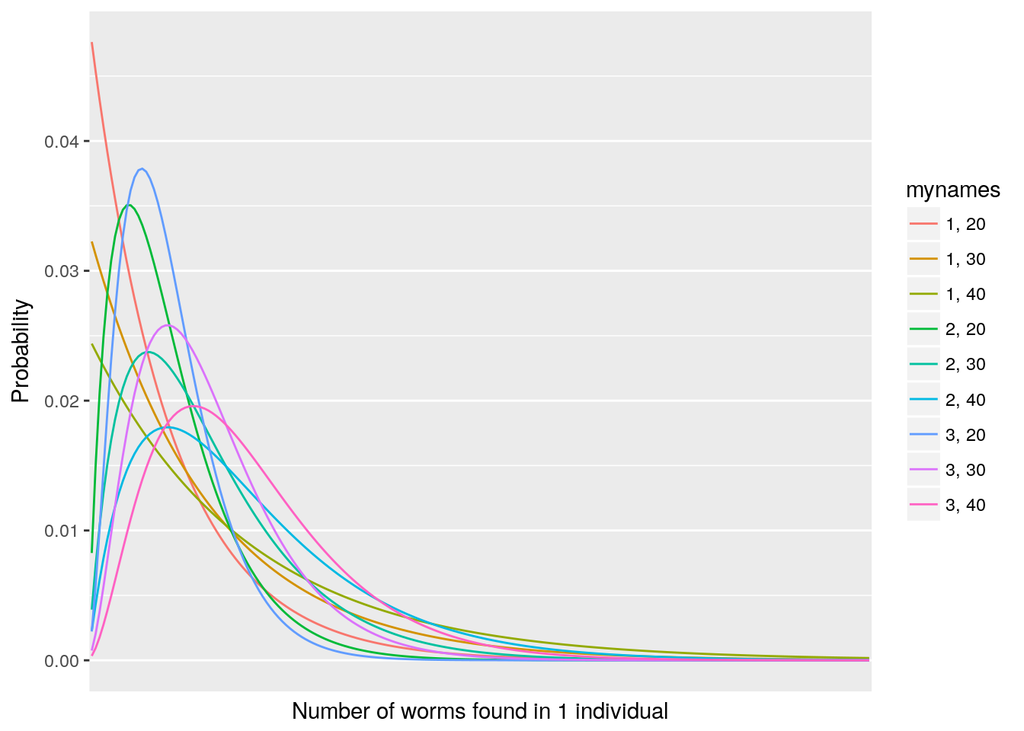

```r
q <- seq(from=0,to=0.1, by=0.001)
myvec <- vector()
mynames <- vector()
for (x in 0:200){
    for (k in 1:3){
        for (meanload in seq(from=20, to=40, by=10)){
            myvec <- c(myvec,dnbinom(x, size=k, mu=meanload)) #alternative:prob=c/k+MeanLoad
            mynames <- c(mynames,paste(k, meanload, sep=", "))
        }
    }
}

x <- vector()
for (i in 0:200) {
    x <- c(x,rep(i,9))
}

mydf <- data.frame(myvec,mynames,x)

ggplot(mydf, aes(x=x, y=myvec, group=mynames, color=mynames))+
    geom_line()+
    scale_x_discrete(name="Number of worms found in 1 individual")+
    scale_y_continuous(name="Probability")
```

```r
#When k increases, A=1/k decreases, less aggregation, tends towards Poisson
```

## 3.1 Simulated data

```r
SimulatedData <- function(Ninds, m1, Dm, alpha, k){
    IndHIs <- runif(Ninds)
    TheMeanLoadModel <- function(HI){
        MeanLoad(m1, Dm, alpha, HI)
    }
    TheMeanLoads <- sapply(IndHIs, TheMeanLoadModel)
    IndLoads  <- rnbinom(Ninds, size=k, mu= TheMeanLoads)
    data.frame(IndHIs, IndLoads)}

TestData <- list(males = SimulatedData(50, 10, 1, 2, 2),
                 females = SimulatedData(50, 10, 9, 2, 2))
#TestData <- list(males = SimulatedData(500, 20, 10, 1, 2),
             #    females = SimulatedData(500, 10, 30, 1, 2))
#TestData[[1]][1,] <- c(0.5, 31) #Stick to Stuart example
```

# 4 PrNegativeBinomialLoad: Probability an Ind has some observed Load, given its HI (and the model)

Function to calculate the density of probability for 1 ind, given his ID (and his HI and Load associated)

```r
PrNegativeBinomialLoad <- function(data, sex, ind, k, m1, Dm, alpha){
    if (sex=="male"){
        HI <- data[[1]][ind,1]
        Load <- data[[1]][ind,2]
    } else {
        HI <- data[[2]][ind,1]
        Load <- data[[2]][ind,2]
    }
    dnbinom(Load, size=k, mu=MeanLoad(m1, Dm, alpha, HI))
}
```

Let’s calculate an example natural Log

```r
log(PrNegativeBinomialLoad(TestData, "male", 5, 2, 0.4, 0.2, 0.0))
```

```
## [1] -2.4202
```

# 5 Generalised … ie the MeanLoad model is passed as an argument (PDF4cMeanLoad)

```r
PrLoad <- function(data, sex, ind, k, m1, Dm, alpha, PDF4cMeanLoad){
    if (sex=="male"){
        HI <- data[[1]][ind,1]
        Load <- data[[1]][ind,2]
    } else {
        HI <- data[[2]][ind,1]
        Load <- data[[2]][ind,2]
    }
    PDF4cMeanLoad(k, MeanLoad(m1, Dm, alpha, HI), Load)
}

SimplePDFNegBin <- function(k, meanLoad, Load){
    dnbinom(Load, size=k, mu=meanLoad)
}
#Always a good idea to make contributions to the likelihood function Bombproof, and never return zero.
PDFNegBin <- function(k, meanLoad, Load){
    max(10^-20, SimplePDFNegBin(abs(k), abs(meanLoad), Load))
}
```

This previous function will be our MeanLoad model function, to be tested for arguments k and alpha through maximum likelihood.

Test:

```r
PrLoad(TestData, "male", 1, 2, 40, 20, 0.2, PDFNegBin)
```

```
## [1] 0.002022179
```

# 6 The likelihood function over a set of inds

‘data’ is two sets/lists of inds (e.g. male and female, hence m1M vs m1F) PDF4cMeanLoad will be a chosen MeanLoad model function (e.g. PDFNegBin) the first argument will be optimised with “optim” later (k, alpha)

All hypotheses: H0: k, alpha, mB H1: k, alpha, mB, DmB H2: k, alpha, m1M, m1F H3: k, alpha, m1M, m1F, DmM, DmF

```r
LikelihoodFunction <- function(param, PDF4cMeanLoad, data, hyp) {
    Sm <- 0 ; Sf <- 0 #initialisation
    if (hyp== "H0"){ #H0: k, alpha, mB
        k <- param[1]; alpha <- param[2]
        mB <- param[3]
        #males
        for (ind in (1:nrow(data[[1]]))){
            Sm <- Sm + log(PrLoad(data, "male", ind, k, mB, 0, alpha, PDF4cMeanLoad))
        }
        #females
        for (ind in (1:nrow(data[[2]]))){
            Sf <- Sf + log(PrLoad(data, "female", ind, k, mB, 0, alpha, PDF4cMeanLoad))
        }
    } else if (hyp== "H1"){ #H1: k, alpha, mB, DmB
        k <- param[1]; alpha <- param[2]
        mB <- param[3]; DmB <- param[4]
        #males
        for (ind in (1:nrow(data[[1]]))){
            Sm <- Sm + log(PrLoad(data, "male", ind, k, mB, DmB, alpha, PDF4cMeanLoad))
        }
        #females
        for (ind in (1:nrow(data[[2]]))){
            Sf <- Sf + log(PrLoad(data, "female", ind, k, mB, DmB, alpha, PDF4cMeanLoad))
        }
    } else if (hyp== "H2"){ #H2: k, alpha, m1M, m1F
        k <- param[1]; alpha <- param[2]
        m1M <- param[3]; m1F <- param[4]
        #males
        for (ind in (1:nrow(data[[1]]))){
            Sm <- Sm + log(PrLoad(data, "male", ind, k, m1M, 0, alpha, PDF4cMeanLoad))
        }
        #females
        for (ind in (1:nrow(data[[2]]))){
            Sf <- Sf + log(PrLoad(data, "female", ind, k, m1F, 0, alpha, PDF4cMeanLoad))
        }
    } else if (hyp== "H3"){ #H3: k, alpha, m1M, m1F, DmM, DmF
        k <- param[1]; alpha <- param[2]
        m1M <- param[3]; m1F <- param[4]
        DmM <- param[5]; DmF <- param[6]
        #males
        for (ind in (1:nrow(data[[1]]))){
            Sm <- Sm + log(PrLoad(data, "male", ind, k, m1M, DmM, alpha, PDF4cMeanLoad))
        }
        #females
        for (ind in (1:nrow(data[[2]]))){
            Sf <- Sf + log(PrLoad(data, "female", ind, k, m1F, DmF, alpha, PDF4cMeanLoad))
        }
    }
    #all
    S <- Sm + Sf #sum of the logs (same as product of the row values) of males and females
    return(S)
}

#Test
LikelihoodFunction(c(2, 0.3, 10, 12, 5, 10), PDFNegBin, TestData, "H3")
```

```
## [1] -336.9434
```

# 7 The Maximum likelihood analysis

Define the function for which we will optimize the parameters: MLE : optim function with box constraints

```r
OptimLikelihood <- function(param){
    return(LikelihoodFunction(param, PDFNegBin, TestData, hyp))}
```

Define the functions to find the parameters bounds: MLEbounds : optim function with constraint on the search

```r
UpperBoundsFunction <- function(hyp, MyMLE){
    if (hyp == "H0"){
        max <- 3
    } else if (hyp =="H1") {
        max <- 4
    } else if (hyp =="H2") {
        max <- 4
    } else if (hyp =="H3") {
        max <- 6
    }
    #empty dataframe to store the data
    summaryVec <- vector()
    for (rankpar in 1:max){ #run over the parameters
        #Functional constraint on search (L > MLE-2) + max&min each param
        OptimBounds <- function(param){
            LK <- LikelihoodFunction(param, PDFNegBin, TestData, hyp)
            if (LK <= (MyMLE$value - 2)){
                if (which_side== "lower"){
                    param[rankpar] <-100
                } else {
                    param[rankpar] <- -100
                }
            }
            return(param[rankpar])
        }
        # Upper bound
        which_side <- "upper"
        MyBoundsMax <- optim(par = MyMLE$par, #initial values for the parameters
                             fn = OptimBounds, #function to be maximized
                             lower = lower, #lower bounds for the parameters
                             upper = upper, #upper bounds for the parameters
                             method = "L-BFGS-B", #set the method
                             control = list(fnscale=-1)) ##turn the default minimizer into maximizer
        summaryVec[rankpar] <- MyBoundsMax$par[rankpar]
    }
    return(summaryVec)
}

LowerBoundsFunction <- function(hyp, MyMLE){
    if (hyp == "H0"){
        max <- 3
    } else if (hyp =="H1") {
        max <- 4
    } else if (hyp =="H2") {
        max <- 4
    } else if (hyp =="H3") {
        max <- 6
    }
    #empty dataframe to store the data
    summaryVec <- vector()
    for (rankpar in 1:max){ #run over the parameters
        #Functional constraint on search (L > MLE-2) + max&min each param
        OptimBounds <- function(param){
            LK <- LikelihoodFunction(param, PDFNegBin, TestData, hyp)
            if (LK <= (MyMLE$value - 2)){
                if (which_side== "lower"){
                    param[rankpar] <-100
                } else {
                    param[rankpar] <- -100
                }
            }
            return(param[rankpar])
        }
        # Lower bound
        which_side <- "lower"
        MyBoundsMin <- optim(par = MyMLE$par, #initial values for the parameters
                             fn = OptimBounds, #function to be maximized
                             lower = lower, #lower bounds for the parameters
                             upper = upper, #upper bounds for the parameters
                             method = "L-BFGS-B") #set the method (Method "L-BFGS-B" from Byrd et. al. (1995))
        summaryVec[rankpar] <- MyBoundsMin$par[rankpar]
    }
    return(summaryVec)
}
```

# 8 H0

```r
hyp <- "H0"

#Constraints:
lower <- c(kmin=0, AlphaLB=-5, min_mB=10)
upper <- c(kmax=8, AlphaUB=5, max_mB=50)
#Starter (likely values) :
start <- c(k=2, Alpha=0, mB=10)

#Optimisation of the parameters:
MyMLE_H0 <- optim(par = start, #initial values for the parameters
                  fn = OptimLikelihood, #function to be maximized
                  lower = lower, #lower bounds for the parameters
                  upper = upper, #upper bounds for the parameters
                  method = "L-BFGS-B", #set the method (Method "L-BFGS-B" from Byrd et. al. (1995))
                  control = list(fnscale=-1)) ##turn the default minimizer into maximizer

#Create the dataframe where I will store the results
summaryDF_H0 <- data.frame(k = numeric(),
                           alpha = numeric(),
                           mB = numeric())
summaryDF_H0[2, ] <- MyMLE_H0$par

##store upper parameter
summaryDF_H0[3, ] <- UpperBoundsFunction("H0", MyMLE_H0)

##store lower parameter
summaryDF_H0[1, ] <- LowerBoundsFunction("H0", MyMLE_H0)

#Results:
print("My Maximum Likelihood is")
```

```
## [1] "My Maximum Likelihood is"
```

```r
MyMLE_H0$value
```

```
## [1] -196.1592
```

```r
summaryDF_H0
```

```
##          k    alpha       mB
## 1 1.830453 2.013769 10.66303
## 2 3.036841 2.013769 12.64349
## 3 5.333865 2.013769 14.94856
```

# 9 H1

```r
hyp <- "H1"

#Constraints:
lower <- c(kmin=0, AlphaLB=-5, min_mB=10, min_DmB=10)
upper <- c(kmax=8, AlphaUB=5, max_mB=50, max_DmB=50)
#Starter (likely values) :
start <- c(k=2, Alpha=0, mB=10, DmB=2)

#Optimisation of the parameters:
MyMLE_H1 <- optim(par = start, #initial values for the parameters
                  fn = OptimLikelihood, #function to be maximized
                  lower = lower, #lower bounds for the parameters
                  upper = upper, #upper bounds for the parameters
                  method = "L-BFGS-B", #set the method (Method "L-BFGS-B" from Byrd et. al. (1995))
                  control = list(fnscale=-1)) ##turn the default minimizer into maximizer

#Create the dataframe where I will store the results
summaryDF_H1 <- data.frame(k = numeric(),
                           alpha = numeric(),
                           mB = numeric(),
                           DmB = numeric())
summaryDF_H1[2, ] <- MyMLE_H1$par

##store upper parameter
summaryDF_H1[3, ] <- UpperBoundsFunction("H1", MyMLE_H1)

##store lower parameter
summaryDF_H1[1, ] <- LowerBoundsFunction("H1", MyMLE_H1)

#Results:
print("My Maximum Likelihood is")
```

```
## [1] "My Maximum Likelihood is"
```

```r
MyMLE_H1$value
```

```
## [1] -195.2753
```

```r
summaryDF_H1
```

```
##          k    alpha       mB      DmB
## 1 1.923996 2.019603 10.00000 10.00000
## 2 3.208278 2.019603 10.00000 10.00000
## 3 5.746076 2.019603 11.23708 12.42853
```

# 10 H2

```r
hyp <- "H2"

#Constraints:
lower <- c(kmin=0, AlphaLB=-5, min_m1M=10, min_m1F=10)
upper <- c(kmax=8, AlphaUB=5, max_m1M=50, max_m1F=50)
#Starter (likely values) :
start <- c(k=2, Alpha=0, m1M=10, m1F=12)

#Optimisation of the parameters:
MyMLE_H2 <- optim(par = start, #initial values for the parameters
                  fn = OptimLikelihood, #function to be maximized
                  lower = lower, #lower bounds for the parameters
                  upper = upper, #upper bounds for the parameters
                  method = "L-BFGS-B", #set the method (Method "L-BFGS-B" from Byrd et. al. (1995))
                  control = list(fnscale=-1)) ##turn the default minimizer into maximizer

#Create the dataframe where I will store the results
summaryDF_H2 <- data.frame(k = numeric(),
                           alpha = numeric(),
                           m1M = numeric(),
                           m1F = numeric())
summaryDF_H2[2, ] <- MyMLE_H2$par

##store upper parameter
summaryDF_H2[3, ] <- UpperBoundsFunction("H2", MyMLE_H2)

##store lower parameter
summaryDF_H2[1, ] <- LowerBoundsFunction("H2", MyMLE_H2)

#Results:
print("My Maximum Likelihood is")
```

```
## [1] "My Maximum Likelihood is"
```

```r
MyMLE_H2$value
```

```
## [1] -192.1962
```

```r
summaryDF_H2
```

```
##          k    alpha      m1M      m1F
## 1 2.096893 1.980521 10.00000 12.58390
## 2 3.601404 2.014433 10.00000 15.63209
## 3 6.508437 2.014433 12.30633 19.40941
```

# 11 H3

```r
hyp <- "H3"

#Constraints:
lower <- c(kmin=0, AlphaLB=-5, min_m1M=10, min_m1F=10, min_DmM=0, min_DmF=0)
upper <- c(kmax=8, AlphaUB=5, max_m1M=50, max_m1F=50, max_DmM=50, max_DmF=50)
#Starter (likely values) :
start <- c(k=2, Alpha=0, m1M=10, m1F=12, DmM=2, DmF=3)

#Optimisation of the parameters:
MyMLE_H3 <- optim(par = start, #initial values for the parameters
                  fn = OptimLikelihood, #function to be maximized
                  lower = lower, #lower bounds for the parameters
                  upper = upper, #upper bounds for the parameters
                  method = "L-BFGS-B", #set the method (Method "L-BFGS-B" from Byrd et. al. (1995))
                  control = list(fnscale=-1)) ##turn the default minimizer into maximizer

#Create the dataframe where I will store the results
summaryDF_H3 <- data.frame(k = numeric(),
                           alpha = numeric(),
                           m1M = numeric(),
                           m1F = numeric(),
                           DmM = numeric(),
                           DmF = numeric())
summaryDF_H3[2, ] <- MyMLE_H3$par

##store upper parameter
summaryDF_H3[3, ] <- UpperBoundsFunction("H3", MyMLE_H3)

##store lower parameter
summaryDF_H3[1, ] <- LowerBoundsFunction("H3", MyMLE_H3)

#Results:
print("My Maximum Likelihood is")
```

```
## [1] "My Maximum Likelihood is"
```

```r
MyMLE_H3$value
```

```
## [1] -189.6177
```

```r
summaryDF_H3
```

```
##          k  alpha     m1M      m1F       DmM       DmF
## 1 2.394352 2.0149 10.0000 10.00000 0.0000000  5.132045
## 2 4.219659 2.0149 10.0000 10.55598 0.9329515 10.913137
## 3 8.000000 2.0149 11.8757 14.08988 5.5910482 19.092862
```

# 12 Test if the difference between 2 likelihood is significant

```r
Gtest <- function(dLL, dDF){
    1 - pchisq(2*dLL, df=dDF)
}

GtestOnNestedMLEs <- function(hyp1, hyp2){
    MyMLE1 <- get(paste0("MyMLE_",hyp1))$value
    MyMLE2 <- get(paste0("MyMLE_",hyp2))$value
    summaryDF1 <- get(paste0("summaryDF_",hyp1))
    summaryDF2 <- get(paste0("summaryDF_",hyp2))
    dLL <- round(abs(MyMLE1 - MyMLE2),4)
    dDF <- abs(length(summaryDF1) - length(summaryDF2))
    p <- round(Gtest(dLL, dDF),4)
    print(paste("Likelihood test between", hyp1, "and", hyp2, ":"))
    print(paste("dLL = ", dLL, " dDF = ", dDF, " Gtest p = ", p))
}
```

# 13 Test the differences of likelihood between each hypotheses and the H0

```r
GtestOnNestedMLEs("H1", "H0")
```

```
## [1] "Likelihood test between H1 and H0 :"
## [1] "dLL =  0.884  dDF =  1  Gtest p =  0.1836"
```

```r
GtestOnNestedMLEs("H2", "H0")
```

```
## [1] "Likelihood test between H2 and H0 :"
## [1] "dLL =  3.963  dDF =  1  Gtest p =  0.0049"
```

```r
GtestOnNestedMLEs("H3", "H0")
```

```
## [1] "Likelihood test between H3 and H0 :"
## [1] "dLL =  6.5415  dDF =  3  Gtest p =  0.0045"
```

# 14 It’s plotting time!!

## 14.1 Plot the mean load model along the hybrid zone, according to the hyp.

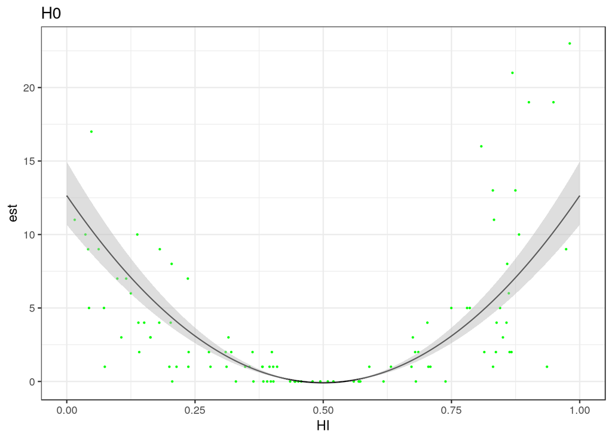

```r
#Formatting TestData for gg_point
TestDataDF_M <- as.data.frame(TestData$males)
TestDataDF_M$sex <- "males"
TestDataDF_F <- as.data.frame(TestData$females)
TestDataDF_F$sex <- "females"
TestDataDF <- rbind(TestDataDF_F, TestDataDF_M)

#H0:
HI <- seq(0,1,0.001)
df <- data.frame(HI,
                 LB=MeanLoad(m1=summaryDF_H0[1,3],
                          Dm=0,
                          alpha=summaryDF_H0[1,2],
                          HI),
                 est=MeanLoad(m1=summaryDF_H0[2,3],
                          Dm=0,
                          alpha=summaryDF_H0[2,2],
                          HI),
                 UB=MeanLoad(m1=summaryDF_H0[3,3],
                          Dm=0,
                          alpha=summaryDF_H0[3,2],
                          HI))

plot0 <- ggplot(df, aes(x=HI, y=est))+
    ggtitle("H0")+
    geom_point(data = TestDataDF, aes(x=IndHIs, y=IndLoads), color= "green", size=0.3)+
    geom_line()+
    geom_ribbon(aes(x=HI, ymax=UB, ymin=LB), fill="grey", alpha=.5)+
    theme_bw()+
    theme(legend.position="none")
plot0
```

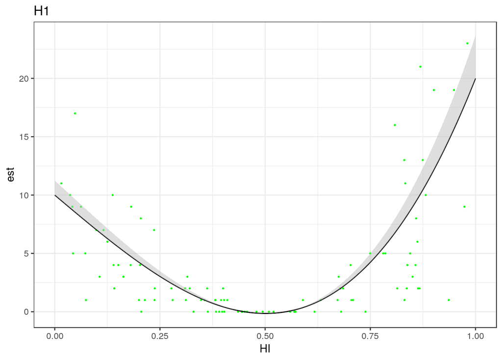

```r
ggsave("plotH0.pdf")
#H1:
df <- data.frame(HI,
                 LB=MeanLoad(m1=summaryDF_H1[1,3],
                          Dm=summaryDF_H1[1,4],
                          alpha=summaryDF_H1[1,2],
                          HI),
                 est=MeanLoad(m1=summaryDF_H1[2,3],
                          Dm=summaryDF_H1[2,4],
                          alpha=summaryDF_H1[2,2],
                          HI),
                 UB=MeanLoad(m1=summaryDF_H1[3,3],
                          Dm=summaryDF_H1[3,4],
                          alpha=summaryDF_H1[3,2],
                          HI))
plot1 <- ggplot(df, aes(x=HI, y=est))+
    ggtitle("H1")+
    geom_point(data = TestDataDF, aes(x=IndHIs, y=IndLoads), color="green", size=0.3)+
    geom_line()+
    geom_ribbon(aes(x=HI, ymax=UB, ymin=LB), fill="grey", alpha=.5)+
    theme_bw()+
    theme(legend.position="none")
plot1
```

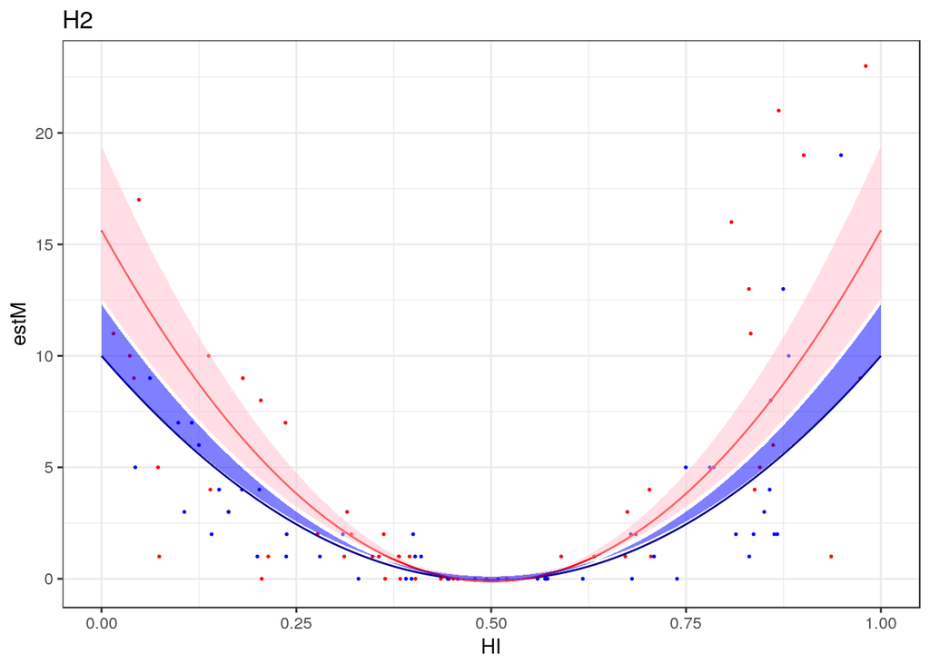

```r
ggsave("plotH1.pdf")
#H2:
df <- data.frame(HI=HI,
                 LBF=MeanLoad(m1=summaryDF_H2[1,4],
                          Dm=0,
                          alpha=summaryDF_H2[1,2],
                          HI),
                 UBF=MeanLoad(m1=summaryDF_H2[3,4],
                          Dm=0,
                          alpha=summaryDF_H2[3,2],
                          HI),
                 estF=MeanLoad(m1=summaryDF_H2[2,4],
                          Dm=0,
                          alpha=summaryDF_H2[2,2],
                          HI),
                 LBM=MeanLoad(m1=summaryDF_H2[1,3],
                          Dm=0,
                          alpha=summaryDF_H2[1,2],
                          HI),
                 UBM=MeanLoad(m1=summaryDF_H2[3,3],
                          Dm=0,
                          alpha=summaryDF_H2[3,2],
                          HI),
                 estM=MeanLoad(m1=summaryDF_H2[2,3],
                          Dm=0,
                          alpha=summaryDF_H2[2,2],
                          HI)
                 )
plot2 <-ggplot(df, aes(x=HI, y=estM))+
    ggtitle("H2")+
    geom_point(data = TestDataDF, aes(x=IndHIs, y=IndLoads, group=sex, color=sex), size=0.3)+
    scale_color_manual(values = c("red", "blue"))+
    geom_line(color="darkblue")+
    geom_line(aes(x=HI, y=estF), color="red")+
    geom_ribbon(aes(x=HI, ymax=UBF, ymin=LBF), fill="pink", alpha=.5)+
    geom_ribbon(aes(x=HI, ymax=UBM, ymin=LBM), fill="blue", alpha=.5)+
    theme_bw()+
    theme(legend.position="none")
plot2
```

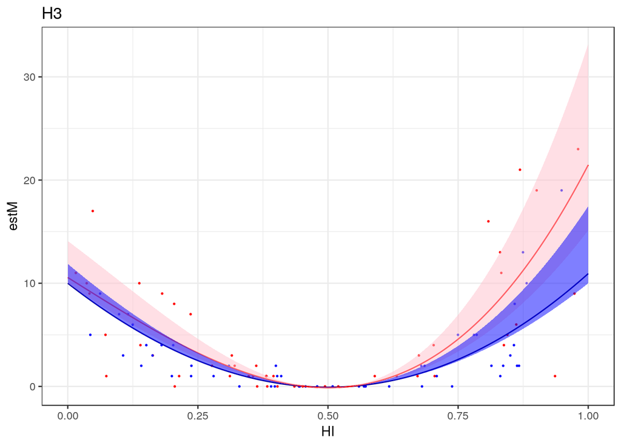

```r
ggsave("plotH2.pdf")
#H3:
df <- data.frame(HI=HI,
                 LBF=MeanLoad(m1=summaryDF_H3[1,4],
                          Dm=summaryDF_H3[1,6],
                          alpha=summaryDF_H3[1,2],
                          HI),
                 UBF=MeanLoad(m1=summaryDF_H3[3,4],
                          Dm=summaryDF_H3[3,6],
                          alpha=summaryDF_H3[3,2],
                          HI),
                 estF=MeanLoad(m1=summaryDF_H3[2,4],
                          Dm=summaryDF_H3[2,6],
                          alpha=summaryDF_H3[2,2],
                          HI),
                 LBM=MeanLoad(m1=summaryDF_H3[1,3],
                          Dm=summaryDF_H3[1,5],
                          alpha=summaryDF_H3[1,2],
                          HI),
                 UBM=MeanLoad(m1=summaryDF_H3[3,3],
                          Dm=summaryDF_H3[3,5],
                          alpha=summaryDF_H3[3,2],
                          HI),
                 estM=MeanLoad(m1=summaryDF_H3[2,3],
                          Dm=summaryDF_H3[2,5],
                          alpha=summaryDF_H3[2,2],
                          HI)
                 )
plot3 <-ggplot(df, aes(x=HI, y=estM))+
    ggtitle("H3")+
    geom_point(data = TestDataDF, aes(x=IndHIs, y=IndLoads, group=sex, color=sex), size=0.3)+
    scale_color_manual(values = c("red", "blue"))+
    geom_line(color="darkblue")+
    geom_line(aes(x=HI, y=estF), color="red")+
    geom_ribbon(aes(x=HI, ymax=UBF, ymin=LBF), fill="pink", alpha=.5)+
    geom_ribbon(aes(x=HI, ymax=UBM, ymin=LBM), fill="blue", alpha=.5)+
    theme_bw()+
    theme(legend.position="none")
plot3
```

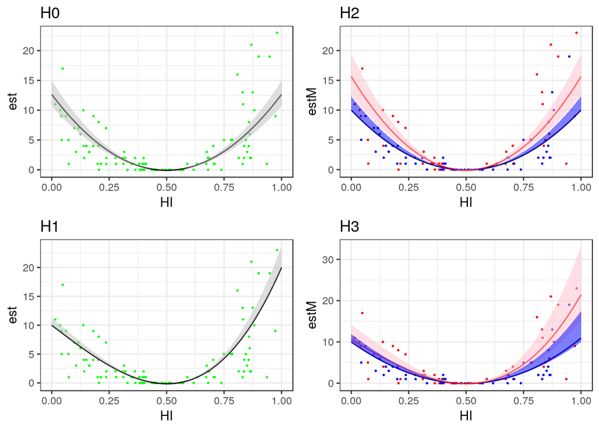

```r
ggsave("plotH3.pdf")
M <- multiplot(plot0,plot1,plot2,plot3, cols=2)
```

```r
M
```